# Table of Contents

```python
import pandas
import quandl
pandas.options.display.float_format = '{:,.4f}'.format
import matplotlib.pyplot as plt

from IPython.core.interactiveshell import InteractiveShell
InteractiveShell.ast_node_interactivity = "all"
```

```python
import quandl # https://github.com/quandl/quandl-python#configuration
api_key = 'qVwroBW_LG9jq9C4THLB'
```

```python
start_date = '2008-09-15'
end_date = '2015-09-15'
```

```python
aapl = quandl.get('WIKI/AAPL.11', start_date=start_date, end_date=end_date, api_key = api_key)
csco = quandl.get('WIKI/CSCO.11', start_date=start_date, end_date=end_date,api_key = api_key)
ibm = quandl.get('WIKI/IBM.11', start_date=start_date, end_date=end_date, api_key = api_key)
amzn = quandl.get('WIKI/AMZN.11', start_date=start_date, end_date=end_date,api_key = api_key)
```

```python
stocks = pandas.concat([aapl,csco,ibm,amzn], axis=1)
stocks.columns = ['aapl', 'csco', 'ibm', 'amzn']
portfolio = [aapl, csco, ibm, amzn]
name = ['aapl', 'csco', 'ibm', 'amzn']
```

## cumulative returns

```python
for index, stock in enumerate(portfolio):
    stock['normalized_retuns'] = stock['Adj. Close']/stock.iloc[0]['Adj. Close']
```

```python
ibm.tail()
```

| Date | Adj. Close | normalized_retuns |
| --- | --- | --- |
| 2015-09-09 | 133.2715 | 1.4544 |
| 2015-09-10 | 134.3281 | 1.4660 |
| 2015-09-11 | 135.4031 | 1.4777 |
| 2015-09-14 | 133.8228 | 1.4605 |
| 2015-09-15 | 135.5501 | 1.4793 |

## portfolio allocations

lets allocate 30% in aapl, 20% in csco, 40% in ibm, 10% in amzn

```python
for stock, allocation in zip(portfolio, [.3,.2,.4,.1]):
    stock['allocation'] = stock['normalized_retuns']*allocation
```

```python
aapl.head()
```

| Date | Adj. Close | normalized_retuns | allocation |
| --- | --- | --- | --- |
| 2008-09-15 | 18.0382 | 1.0000 | 0.3000 |
| 2008-09-16 | 17.9765 | 0.9966 | 0.2990 |
| 2008-09-17 | 16.4279 | 0.9107 | 0.2732 |
| 2008-09-18 | 17.2324 | 0.9553 | 0.2866 |
| 2008-09-19 | 18.1089 | 1.0039 | 0.3012 |

```python
capital = 1000000

for index, stock in enumerate(portfolio):
    stock['position_'+str(name[index])] = stock.allocation*capital
```

```python
aapl.head()
```

| Date | Adj. Close | normalized_retuns | allocation | position_aapl |
| --- | --- | --- | --- | --- |
| 2008-09-15 | 18.0382 | 1.0000 | 0.3000 | 300,000.0000 |
| 2008-09-16 | 17.9765 | 0.9966 | 0.2990 | 298,974.0667 |
| 2008-09-17 | 16.4279 | 0.9107 | 0.2732 | 273,218.8658 |
| 2008-09-18 | 17.2324 | 0.9553 | 0.2866 | 286,598.7461 |
| 2008-09-19 | 18.1089 | 1.0039 | 0.3012 | 301,175.5486 |

## total positions

```python
portfolio_positions = pandas.concat([aapl.position_aapl,
                                    csco.position_csco,
                                    ibm.position_ibm,
                                    amzn.position_amzn]
                                   , axis=1)
```

```python
portfolio_positions['total_position']= portfolio_positions.sum(axis=1)
```

```python
portfolio_positions.head()
```

| Date | position_aapl | position_csco | position_ibm | position_amzn | total_position |
| --- | --- | --- | --- | --- | --- |
| 2008-09-15 | 300,000.0000 | 200,000.0000 | 400,000.0000 | 100,000.0000 | 1,000,000.0000 |
| 2008-09-16 | 298,974.0667 | 203,753.3512 | 402,986.3703 | 101,797.2589 | 1,007,511.0471 |
| 2008-09-17 | 273,218.8658 | 194,816.8007 | 387,082.2120 | 92,500.6465 | 947,618.5250 |
| 2008-09-18 | 286,598.7461 | 203,753.3512 | 399,756.9233 | 98,913.8867 | 989,022.9074 |
| 2008-09-19 | 301,175.5486 | 217,068.8114 | 412,709.4366 | 104,732.3507 | 1,035,686.1473 |

## plot periodical positions

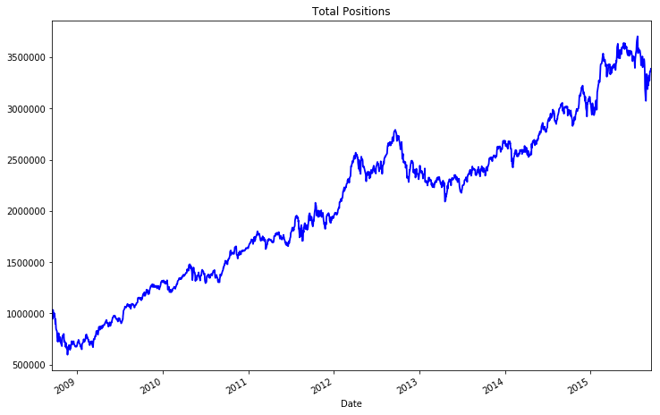

```python
portfolio_positions.total_position.plot(figsize=(12,8), lw=1.8, c='blue');
plt.title('Total Positions');
```

`Individual positions`

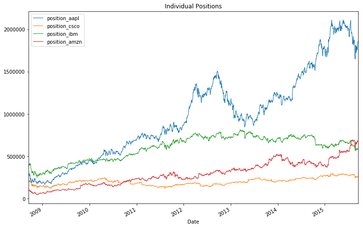

```python
portfolio_positions.drop('total_position', axis=1).plot(figsize=(12,8), lw=1);
plt.title('Individual Positions');
```

`aapl seems to outperform all the stocks , how can invest smart ? How do actually choose what is the optimal amount of capital we should invest in each security so that we maximize our profits`

## sharpe ratio

```python
portfolio_positions.head()
```

| Date | position_aapl | position_csco | position_ibm | position_amzn | total_position |
| --- | --- | --- | --- | --- | --- |
| 2008-09-15 | 300,000.0000 | 200,000.0000 | 400,000.0000 | 100,000.0000 | 1,000,000.0000 |
| 2008-09-16 | 298,974.0667 | 203,753.3512 | 402,986.3703 | 101,797.2589 | 1,007,511.0471 |
| 2008-09-17 | 273,218.8658 | 194,816.8007 | 387,082.2120 | 92,500.6465 | 947,618.5250 |
| 2008-09-18 | 286,598.7461 | 203,753.3512 | 399,756.9233 | 98,913.8867 | 989,022.9074 |
| 2008-09-19 | 301,175.5486 | 217,068.8114 | 412,709.4366 | 104,732.3507 | 1,035,686.1473 |

```python
portfolio_positions['daily_return'] = portfolio_positions.total_position.pct_change(1)
portfolio_positions.head()
```

| Date | position_aapl | position_csco | position_ibm | position_amzn | total_position | daily_return |
| --- | --- | --- | --- | --- | --- | --- |
| 2008-09-15 | 300,000.0000 | 200,000.0000 | 400,000.0000 | 100,000.0000 | 1,000,000.0000 | nan |
| 2008-09-16 | 298,974.0667 | 203,753.3512 | 402,986.3703 | 101,797.2589 | 1,007,511.0471 | 0.0075 |
| 2008-09-17 | 273,218.8658 | 194,816.8007 | 387,082.2120 | 92,500.6465 | 947,618.5250 | -0.0594 |
| 2008-09-18 | 286,598.7461 | 203,753.3512 | 399,756.9233 | 98,913.8867 | 989,022.9074 | 0.0437 |
| 2008-09-19 | 301,175.5486 | 217,068.8114 | 412,709.4366 | 104,732.3507 | 1,035,686.1473 | 0.0472 |

`mean daily returns`

```python
Rp = portfolio_positions.daily_return.mean()
```

`daily standard deviation / volatility`

```python
std = portfolio_positions.daily_return.std()
```

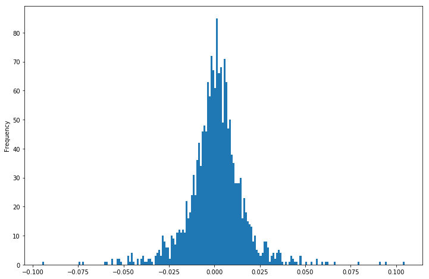

```python
portfolio_positions.daily_return.plot(kind='hist', bins=200, figsize=(12,8));
```

## cumulative return

```python
cumulative_return = (portfolio_positions.total_position[-1]/portfolio_positions.total_position[0]-1)*100
```

```python
cumulative_return
```

```
238.7508402202137
```

```python
portfolio_positions.total_position[-1]
```

```
3387508.402202137
```

## sharpe ratio

```python
# annualized sharpe ratio
Rf=0
import numpy as np
SR = (Rp-Rf)/std
ASR = SR*np.sqrt(252)
```

```python
SR
```

```
0.052897524930990106
```

```python
ASR
```

```
0.8397221756294336
```

`sharpe ratio > 1 means the portfolio has out performed the market`

## efficient frontier

```python
stocks.head()
```

| Date | aapl | csco | ibm | amzn |
| --- | --- | --- | --- | --- |
| 2008-09-15 | 18.0382 | 18.4943 | 91.6303 | 77.3400 |
| 2008-09-16 | 17.9765 | 18.8414 | 92.3144 | 78.7300 |
| 2008-09-17 | 16.4279 | 18.0150 | 88.6711 | 71.5400 |
| 2008-09-18 | 17.2324 | 18.8414 | 91.5746 | 76.5000 |
| 2008-09-19 | 18.1089 | 20.0726 | 94.5417 | 81.0000 |

```python
## mean returns
pandas.options.display.float_format = '{:,.6f}'.format
stocks.pct_change(1).mean()
```

```
aapl   0.001245
csco   0.000349
ibm    0.000327
amzn   0.001410
dtype: float64
```

```python
## lets see correlation between stock returns
stocks.pct_change(1).corr()
```

|  | aapl | csco | ibm | amzn |
| --- | --- | --- | --- | --- |
| aapl | 1.000000 | 0.509564 | 0.512681 | 0.449653 |
| csco | 0.509564 | 1.000000 | 0.588108 | 0.463036 |
| ibm | 0.512681 | 0.588108 | 1.000000 | 0.455959 |
| amzn | 0.449653 | 0.463036 | 0.455959 | 1.000000 |

`csco and ibm seems to have good correlation , here driving factor for this correlation is not because of the individual relationship between csco and ibm , its because the driving factor is external meaning returns of these stocks are driven by external factor`

`this correlation is deceiving since it is not a true correlation`

## log returns

`why we use log returns in finance?`

Because it is approximately good: for short periods (e.g., daily), the log returns approximates the discrete returns

`One of the big reasons for using them is they are additive. You can add log returns, but you can’t add simple returns. (You must compound them.)` `e.g. two-period log return is identical to the sum of the each period’s log return. To get the n-period log return, we can simply add the consecutive single period log returns.`

It is also Mathematically convenient: logs and exponents are easier to manipulate with calculus. Theoretical models tend to assume, unrealistically but conveniently, continuously compounded rates of return. For example, if LogReturn = LN(P1/P0), then EXP[LogReturn] = P1/P0. If f(y) = EXP[LogReturn] then the first derivative, f’(y) is quite wonderfully also EXP[LogReturn]. In short, d/dx EXP[x] = EXP[x].

`There are many calculations that are easier with log returns, especially time series applications.`

`If $100 grows to $120, what is the single period return?`

Discretely... +20% because 120/100-1 = 20% Continuously... log return is given by LN(P1/P0) or ~18.2%. (If the asset paid dividends, they are included in the numerator).

Period log returns are typically used in quantitative finance

**Drawbacks of log return**

- Not "linear" in portfolio return: We would like to be able to say that portfolio return is a weighted sum of components (assets). However, we cannot say this under log returns: the log return is not linearly additive across portfolio components. But, the discrete return is linearly additive.
- Unrealistic: Markets tend to quote discrete returns

if prices are lognormally distributed meaning that pi,pj are assumed to be lognormally distributed. Then it is easy to verify that pi,pj is also lognormal. Hence, by the definition of the lognormal distribution, log(pi/pj)=log(1+ri) is normally distributed.

source: wikipedia, http://mktlssns.blogspot.com, Reference: Hudson, Robert and Gregoriou, Andros, Calculating and Comparing Security Returns is Harder than you Think: A Comparison between Logarithmic and Simple Returns (February 7, 2010). Available at SSRN: https://ssrn.com/abstract=1549328 or http://dx.doi.org/10.2139/ssrn.1549328

```python
log_returns = np.log(stocks/stocks.shift(1))
log_returns.head()
```

| Date | aapl | csco | ibm | amzn |
| --- | --- | --- | --- | --- |
| 2008-09-15 | nan | nan | nan | nan |
| 2008-09-16 | -0.003426 | 0.018593 | 0.007438 | 0.017813 |
| 2008-09-17 | -0.090084 | -0.044851 | -0.040266 | -0.095768 |
| 2008-09-18 | 0.047810 | 0.044851 | 0.032220 | 0.067034 |
| 2008-09-19 | 0.049610 | 0.063304 | 0.031887 | 0.057158 |

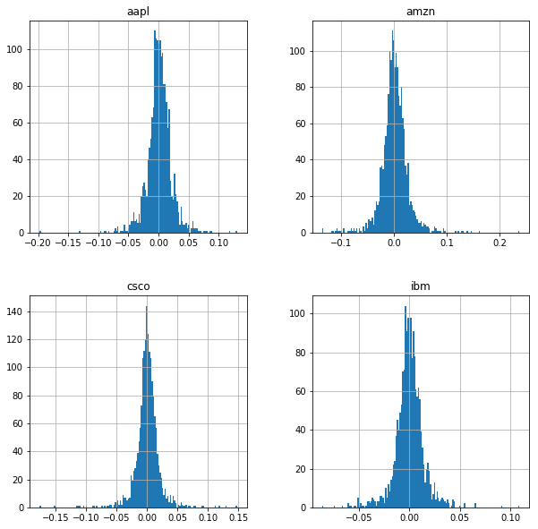

```python
log_returns.hist(bins=150, figsize=(10,10));
```

## paiwise covarience of log returns

```python
log_returns.cov() # daily
```

|  | aapl | csco | ibm | amzn |
| --- | --- | --- | --- | --- |
| aapl | 0.000419 | 0.000208 | 0.000151 | 0.000237 |
| csco | 0.000208 | 0.000401 | 0.000169 | 0.000237 |
| ibm | 0.000151 | 0.000169 | 0.000209 | 0.000169 |
| amzn | 0.000237 | 0.000237 | 0.000169 | 0.000646 |

```python
log_returns.cov() * 252 # annualized
```

|  | aapl | csco | ibm | amzn |
| --- | --- | --- | --- | --- |
| aapl | 0.105568 | 0.052346 | 0.038124 | 0.059619 |
| csco | 0.052346 | 0.101170 | 0.042704 | 0.059830 |
| ibm | 0.038124 | 0.042704 | 0.052793 | 0.042639 |
| amzn | 0.059619 | 0.059830 | 0.042639 | 0.162816 |

```python
log_returns.mean()
```

```
aapl   0.001036
csco   0.000149
ibm    0.000222
amzn   0.001084
dtype: float64
```

## efficient frontier

```python
np.random.seed(42)
print(stocks.columns)
w= np.random.random(4)
w = w /np.sum(w)
w
```

```
Index(['aapl', 'csco', 'ibm', 'amzn'], dtype='object')
```

```
array([0.14102156, 0.35796222, 0.27560979, 0.22540643])
```

```python
# expected weighted return Rp = [r1,r2.....][w1,w2......].T
Rp = (log_returns.mean()*252*w).sum()
Rp
```

```
0.12723632594514112
```

```python
from IPython.display import Image
Image(filename='image.GIF')
```

[output not shown]

```python
# expected volatily
variance = np.dot(w.T, np.dot(log_returns.cov()*252,w))  # 252 trading days
volatility = variance**.5
```

```python
# sharpe ratio
Rf=0
SR = (Rp-Rf)/volatility
SR
```

```
0.5078763475040815
```

## simulation of 5000 portfolio with random weights allocated

```python
np.random.seed(42)

n=5000 # total portfolios
# w-weights, Rp-daily returns
W = np.zeros((n,len(stocks.columns)))
Rp = np.zeros(n)
Rf=0
std = np.zeros(n)
SR = np.zeros(n)

for i in range(n):
    w= np.random.random(4)
    w = w /np.sum(w)
    W[i,:] = w

    Rp[i] = (log_returns.mean()*252*w).sum()
    std[i] = np.sqrt(np.dot(w.T, np.dot(log_returns.cov()*252,w)))

    SR[i] = (Rp[i]-Rf)/std[i]

Rp_montecarlo = Rp.copy()
std_montecarlo = std.copy()
SR_montecarlo = SR.copy()
```

```python
SR_max = SR.max()
SR_max
```

```
0.8639952520179804
```

```python
W
```

```
array([[0.14102156, 0.35796222, 0.27560979, 0.22540643],
       [0.12620081, 0.1261813 , 0.04698284, 0.70063506],
       [0.2613905 , 0.30790022, 0.00895102, 0.42175826],
       ...,
       [0.09393054, 0.37660598, 0.22806641, 0.30139707],
       [0.03792625, 0.20873329, 0.38175439, 0.37158606],
       [0.04845678, 0.314356  , 0.45887721, 0.17831001]])
```

```python
SR_max_index = SR.argmax() # index location of max element in the numpy array
SR_max_index
```

```
704
```

```python
W[SR_max_index,:] # optimum allocation
```

```
array([0.56882301, 0.01379954, 0.01030534, 0.4070721 ])
```

```python
SR
```

```
array([0.50787635, 0.69896867, 0.67602058, ..., 0.51171681, 0.54515473,
       0.41449574])
```

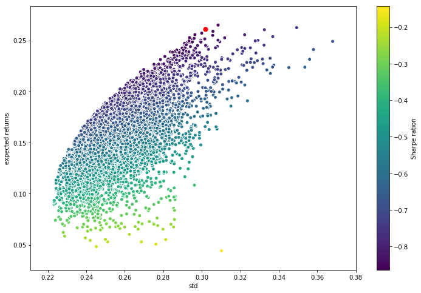

```python
fig, ax = plt.subplots(figsize=(12,8))
plt.scatter(std,Rp, c=-SR,edgecolors='white');
plt.colorbar(label='Sharpe ration');
plt.xlabel('std');
plt.ylabel('expected returns');
plt.scatter(std[SR_max_index], Rp[SR_max_index], c='r', s=50);
```

## How about using some optimizer to get the job done instead of random simulations

```python
def efficient_frontier(w):
    Rf=0
    Rp = (log_returns.mean()*252*w).sum()
    std = np.sqrt(np.dot(w.T, np.dot(log_returns.cov()*252,w)))
    SR = (Rp-Rf)/std
    return [Rp,std,SR]
```

```python
from scipy.optimize import minimize
```

```python
def neg_sharpe(w):
    return -efficient_frontier(w)[2]
```

```python
def checksum(w):
    return w.sum()-1
```

```python
constraint = ({'type':'eq', 'fun': checksum})
bounds = ((0,1), (0,1), (0,1), (0,1))
```

```python
initial_w = [0.25, 0.25, 0.25, 0.25]
```

```python
optimum_weights = minimize(neg_sharpe,initial_w, method='SLSQP',bounds=bounds, constraints=constraint)
optimum_weights
```

```
     fun: -0.8761983622799034
     jac: array([-4.40329313e-06,  4.01284434e-01,  1.94373608e-01,  8.73953104e-06])
 message: 'Optimization terminated successfully.'
    nfev: 30
     nit: 5
    njev: 5
  status: 0
 success: True
       x: array([6.63641352e-01, 1.21972744e-16, 3.55618313e-17, 3.36358648e-01])
```

```python
optimum_weights.x
```

```
array([6.63641352e-01, 1.21972744e-16, 3.55618313e-17, 3.36358648e-01])
```

```python
efficient_frontier(optimum_weights.x)
```

```
[0.26508623319001523, 0.30254134748694367, 0.8761983622799034]
```

`[Rp,std,SR] is now (0.26508623319001523, 0.30254134748694367, 0.8761983622799034)`

```python
expected_returns = np.linspace(0.05,0.26,50)
```

```python
def minimize_volatility(w):
    return efficient_frontier(w)[1]
```

```python
markovitz_frontier_volatility = []

for r in expected_returns:
    constraint = ({'type':'eq', 'fun': checksum}, {'type':'eq', 'fun':lambda w:efficient_frontier(w)[0]-r})
    result =  minimize(minimize_volatility, initial_w, method='SLSQP', bounds= bounds, constraints=constraint)
    markovitz_frontier_volatility.append(result.fun)
```

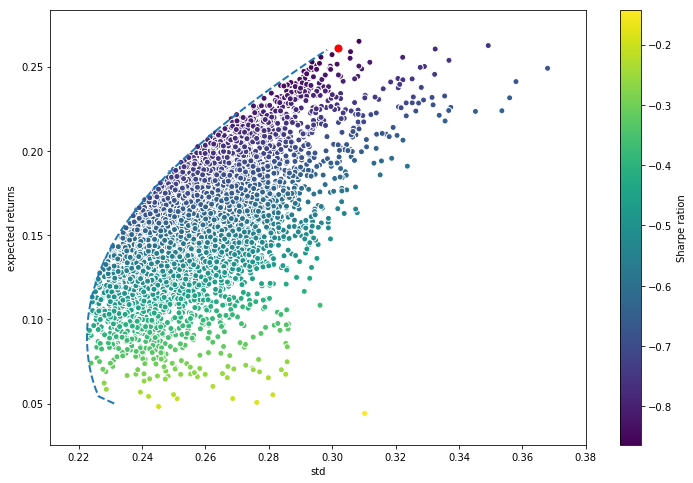

```python
fig, ax = plt.subplots(figsize=(12,8))
plt.scatter(std_montecarlo,Rp_montecarlo, c=-SR_montecarlo,edgecolors='white');
plt.colorbar(label='Sharpe ration');
plt.xlabel('std');
plt.ylabel('expected returns');
plt.scatter(std_montecarlo[SR_max_index], Rp_montecarlo[SR_max_index], c='r', s=50);

plt.plot(markovitz_frontier_volatility, expected_returns, lw=2, ls='--');
```

Reference: https://kyle-stahl-mn.com/stock-portfolio-optimization#Convex-Optimization-in-Python Investopedia, wikipedia